# Alternative to kable function when knitting to MS word

### Note

For those who want to shadow this process, you may need two packages, `tidyverse` and `flextable`. This memo has been created under R version 3.5.1 (2018-07-02).

### 1. Overview

You may be sick and tired of broken table by `kable()` in `knitr` package when outputting your report to Microsoft Word format. Here is my alternative to `kable()` function using `flextable` package. The example below used `mtcars` dataset.

### 2. Fixing automatic rowname drop problem

Unlike `kable()` function, table formats in the `flextable` package automatically **drops your rownames of your dataframe**. In order to prevent this, we can use `colkey =` option in `regulartable()` or `flextable()` function. It is convenient when you create a dataset. However, it is not when you just format your data frame with long rownames. My suggestion is to save the rownames as a new column before formatting.

```r
dat <- mtcars[, 1:6] %>%
    mutate(model = rownames(mtcars)) %>%
    select(ncol(.), 1:(ncol(.)-1))
```

### 3. Formatting the table

- Basic theme: `regulartable()`, `flextable()`
- Automatic column width adjustment by `autofit()`

First of all, let’s start with the basic theme functions in the `flextable` package: `regulartable()` and `flextable()`.

```r
dat %>% head() %>% regulartable()
```

| model | mpg | cyl | disp | hp | drat | wt |
| --- | --- | --- | --- | --- | --- | --- |
| Mazda RX4 | 21.000 | 6.000 | 160.000 | 110.000 | 3.900 | 2.620 |
| Mazda RX4 Wag | 21.000 | 6.000 | 160.000 | 110.000 | 3.900 | 2.875 |
| Datsun 710 | 22.800 | 4.000 | 108.000 | 93.000 | 3.850 | 2.320 |
| Hornet 4 Drive | 21.400 | 6.000 | 258.000 | 110.000 | 3.080 | 3.215 |
| Hornet Sportabout | 18.700 | 8.000 | 360.000 | 175.000 | 3.150 | 3.440 |
| Valiant | 18.100 | 6.000 | 225.000 | 105.000 | 2.760 | 3.460 |

```r
dat %>% head() %>% flextable()
```

| model | mpg | cyl | disp | hp | drat | wt |
| --- | --- | --- | --- | --- | --- | --- |
| Mazda RX4 | 21.000 | 6.000 | 160.000 | 110.000 | 3.900 | 2.620 |
| Mazda RX4 Wag | 21.000 | 6.000 | 160.000 | 110.000 | 3.900 | 2.875 |
| Datsun 710 | 22.800 | 4.000 | 108.000 | 93.000 | 3.850 | 2.320 |
| Hornet 4 Drive | 21.400 | 6.000 | 258.000 | 110.000 | 3.080 | 3.215 |
| Hornet Sportabout | 18.700 | 8.000 | 360.000 | 175.000 | 3.150 | 3.440 |
| Valiant | 18.100 | 6.000 | 225.000 | 105.000 | 2.760 | 3.460 |

In case the width of your table needs adjusting, make use of `autofit()` function. It will automatically adjust your table’s column width.

```r
head(dat) %>%
    regulartable() %>%
    autofit()
```

| model | mpg | cyl | disp | hp | drat | wt |
| --- | --- | --- | --- | --- | --- | --- |
| Mazda RX4 | 21.000 | 6.000 | 160.000 | 110.000 | 3.900 | 2.620 |
| Mazda RX4 Wag | 21.000 | 6.000 | 160.000 | 110.000 | 3.900 | 2.875 |
| Datsun 710 | 22.800 | 4.000 | 108.000 | 93.000 | 3.850 | 2.320 |
| Hornet 4 Drive | 21.400 | 6.000 | 258.000 | 110.000 | 3.080 | 3.215 |
| Hornet Sportabout | 18.700 | 8.000 | 360.000 | 175.000 | 3.150 | 3.440 |
| Valiant | 18.100 | 6.000 | 225.000 | 105.000 | 2.760 | 3.460 |

### 4. Add a footnote at the bottom of your table

- Add a footer (footnote) at the bottom of the table: `add_footer()`
- Merge the bottom row for footer space: `merge_at()`

When you want to attach a footnote at the bottom of your table, you can use `add_footer()` function in the `flextable` package. Howver, there is some tricky part to understand how this function works. First of all, you have to specify the place where your footnote begins by column name.

- add_footer([your dataframe], [column name] = “text”)

Moreover, your footnote will goes to the second line easily, if you only apply this function in adition to your previous code.

```r
head(dat) %>%
    regulartable() %>%
    autofit() %>%
    add_footer(., model = "* The data was extracted from the 1974 Motor Trend US magazine, and comprises fuel consumption and 10 aspects of automobile design and performance for 32 automobiles (1973–74 models).")
```

| model | mpg | cyl | disp | hp | drat | wt |
| --- | --- | --- | --- | --- | --- | --- |
| Mazda RX4 | 21.000 | 6.000 | 160.000 | 110.000 | 3.900 | 2.620 |
| Mazda RX4 Wag | 21.000 | 6.000 | 160.000 | 110.000 | 3.900 | 2.875 |
| Datsun 710 | 22.800 | 4.000 | 108.000 | 93.000 | 3.850 | 2.320 |
| Hornet 4 Drive | 21.400 | 6.000 | 258.000 | 110.000 | 3.080 | 3.215 |
| Hornet Sportabout | 18.700 | 8.000 | 360.000 | 175.000 | 3.150 | 3.440 |
| Valiant | 18.100 | 6.000 | 225.000 | 105.000 | 2.760 | 3.460 |

* The data was extracted from the 1974 Motor Trend US magazine, and comprises fuel consumption and 10 aspects of automobile design and performance for 32 automobiles (1973–74 models).

This happens because there are invisible compartments between columns at the footnote row. In order to fix this problem, we need to merge the footnote’s row by using `merge_at()` function in the `flextable` package.

```r
head(dat) %>%
    regulartable() %>%
    autofit() %>%
    add_footer(., model = "* The data was extracted from the 1974 Motor Trend US magazine, and comprises fuel consumption and 10 aspects of automobile design and performance for 32 automobiles (1973–74 models).") %>%
    merge_at(., i=1, j = 1:ncol(dat), part = "footer")
```

| model | mpg | cyl | disp | hp | drat | wt |
| --- | --- | --- | --- | --- | --- | --- |
| Mazda RX4 | 21.000 | 6.000 | 160.000 | 110.000 | 3.900 | 2.620 |
| Mazda RX4 Wag | 21.000 | 6.000 | 160.000 | 110.000 | 3.900 | 2.875 |
| Datsun 710 | 22.800 | 4.000 | 108.000 | 93.000 | 3.850 | 2.320 |
| Hornet 4 Drive | 21.400 | 6.000 | 258.000 | 110.000 | 3.080 | 3.215 |
| Hornet Sportabout | 18.700 | 8.000 | 360.000 | 175.000 | 3.150 | 3.440 |
| Valiant | 18.100 | 6.000 | 225.000 | 105.000 | 2.760 | 3.460 |

* The data was extracted from the 1974 Motor Trend US magazine, and comprises fuel consumption and 10 aspects of automobile design and performance for 32 automobiles (1973–74 models).

If you want to add multiple footnotes at the bottom of your table, you can change the row number `i=1` to `i=2` and determine whether it goes above or below the first footnote by using `top=` option.

```r
head(dat) %>%
    regulartable() %>%
    autofit() %>%
    add_footer(., model = "* The data was extracted from the 1974 Motor Trend US magazine, and comprises fuel consumption and 10 aspects of automobile design and performance for 32 automobiles (1973–74 models).") %>%
    merge_at(., i = 1, j = 1:ncol(dat), part = "footer") %>%
    add_footer(., model = "** This is a data frame with 32 observations on 11 (numeric) variables. The source is from Henderson and Velleman (1981), Building multiple regression models interactively. Biometrics, 37, 391–411.", top = F) %>%
    merge_at(., i=2, j = 1:ncol(dat), part = "footer")
```

| model | mpg | cyl | disp | hp | drat | wt |
| --- | --- | --- | --- | --- | --- | --- |
| Mazda RX4 | 21.000 | 6.000 | 160.000 | 110.000 | 3.900 | 2.620 |
| Mazda RX4 Wag | 21.000 | 6.000 | 160.000 | 110.000 | 3.900 | 2.875 |
| Datsun 710 | 22.800 | 4.000 | 108.000 | 93.000 | 3.850 | 2.320 |
| Hornet 4 Drive | 21.400 | 6.000 | 258.000 | 110.000 | 3.080 | 3.215 |
| Hornet Sportabout | 18.700 | 8.000 | 360.000 | 175.000 | 3.150 | 3.440 |
| Valiant | 18.100 | 6.000 | 225.000 | 105.000 | 2.760 | 3.460 |

* The data was extracted from the 1974 Motor Trend US magazine, and comprises fuel consumption and 10 aspects of automobile design and performance for 32 automobiles (1973–74 models).  
** This is a data frame with 32 observations on 11 (numeric) variables. The source is from Henderson and Velleman (1981), Building multiple regression models interactively. Biometrics, 37, 391–411.

### 5. Add a header (i.e. caption or table title) at the top of your table

- Add a table title: `add_header()`
- Merge the row for header space: `merge_at()`
- Align the row: `align()`

In addition to footnotes, you may want to attach a title of your table. It is quite similar to footnote method.

```r
head(dat) %>%
    regulartable() %>%
    autofit() %>%
    add_footer(., model = "* The data was extracted from the 1974 Motor Trend US magazine, and comprises fuel consumption and 10 aspects of automobile design and performance for 32 automobiles (1973–74 models).") %>%
    merge_at(., i = 1, j = 1:ncol(dat), part = "footer") %>%
    add_footer(., model = "** This is a data frame with 32 observations on 11 (numeric) variables. The source is from Henderson and Velleman (1981), Building multiple regression models interactively. Biometrics, 37, 391–411.", top = F) %>%
    merge_at(., i=2, j = 1:ncol(dat), part = "footer") %>%
    add_header(., model = "Table1. First six car models in the mtcars dataset", top = T) %>%
    merge_at(., i = 1, j = 1:ncol(dat), part = "header") %>%
    align(., i = 1, j = 1:ncol(dat), align = "center", part = "header")
```

| Table1. First six car models in the mtcars dataset model | Table1. First six car models in the mtcars dataset mpg | Table1. First six car models in the mtcars dataset cyl | Table1. First six car models in the mtcars dataset disp | Table1. First six car models in the mtcars dataset hp | Table1. First six car models in the mtcars dataset drat | Table1. First six car models in the mtcars dataset wt |
| --- | --- | --- | --- | --- | --- | --- |
| Mazda RX4 | 21.000 | 6.000 | 160.000 | 110.000 | 3.900 | 2.620 |
| Mazda RX4 Wag | 21.000 | 6.000 | 160.000 | 110.000 | 3.900 | 2.875 |
| Datsun 710 | 22.800 | 4.000 | 108.000 | 93.000 | 3.850 | 2.320 |
| Hornet 4 Drive | 21.400 | 6.000 | 258.000 | 110.000 | 3.080 | 3.215 |
| Hornet Sportabout | 18.700 | 8.000 | 360.000 | 175.000 | 3.150 | 3.440 |
| Valiant | 18.100 | 6.000 | 225.000 | 105.000 | 2.760 | 3.460 |

* The data was extracted from the 1974 Motor Trend US magazine, and comprises fuel consumption and 10 aspects of automobile design and performance for 32 automobiles (1973–74 models).  
** This is a data frame with 32 observations on 11 (numeric) variables. The source is from Henderson and Velleman (1981), Building multiple regression models interactively. Biometrics, 37, 391–411.

### 6. Output example in Microsoft Word

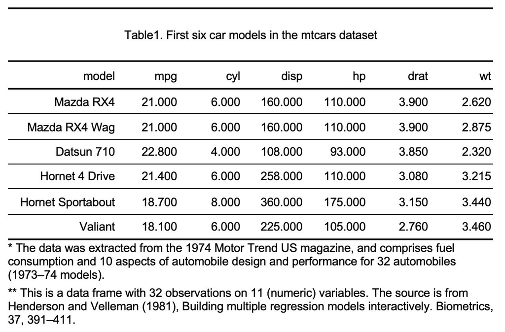

Reference: https://cran.r-project.org/web/packages/flextable/flextable.pdf

(End of document)